# Genetic Data / Tutorial - QMSS 2016

chiara

14 May 2016

# Handling sequence data

Handling genetic alignments, genetic distance, trees, genetic distance between populations. Sequence data from Barbieri et al. 2013 “Unraveling the Complex Maternal History of Southern African Khoisan Populations”" (mitochondrial sequences mtDNA) Original sequences are deposited at http://www.ncbi.nlm.nih.gov/popset?DbFrom=nuccore&Cmd=Link&LinkName=nuccore_popset&IdsFromResult=444211048

## 1. Sequence alignment

Start loading the libraries you will need:

```r
library(ape, adegenet)
library(phangorn)
library (lattice)
library (ca)
library(MASS)
```

Import the sequence data

```r
seq<-read.dna("BOTNAM_imputed_noNno54.fasta", format="fasta")
```

*IMPUTATION* Here I use an imputed DNA alignment to minimize the amount of missing data, and the consequent uncertainity in phylogenetic reconstruction! Positions with missing data were replaced by the same base of the closest sequences in the whole dataset.

Import an info file that has information for each individual sequence.

```r
info<-read.table("infomtDNAcomparison.txt",  sep="\t", header=T, as.is=T, fill=TRUE)
seq <-seq[info$ID,]
```

it’s quite a big alignment!

```r
print(seq)
```

```
## 659 DNA sequences in binary format stored in a matrix.
##
## All sequences of same length: 16549
##
## Labels: Neandertal NAM076 NAM078 NAM079 NAM080 NAM081 ...
##
## More than 1 million nucleotides: not printing base composition
```

I can choose a subset of 100 sequences, randomly sampled. I also save a fasta alignment with those 100 sequences.

```
infoRED<-info[sample(nrow(info), 100),]
seqRED<-seq[infoRED$ID,]
write.dna(seqRED, "reducedSet100sequences.fasta",colsep="", nbcol=10000, blocksep=0, format="fasta")
```

# 2. Tree based on individual distances - NJ

Now we calculate a simple genetic distance between sequences.

```r
dist.matrix <- dist.dna(seq) # Calculate distance matrix
m5<- as.dist(dist.matrix, diag=F, upper=F)
```

We create a Neighbour Joining tree from the matrix of pairwise distance

```r
treeRED<-nj(m5)   #create the object neighbour joining tree
treeRED$edge.length[treeRED$edge.length < 0] = 0.002 #little trick to avoid negative branches
```

Here’s a little command to make a list of colors to assign to the sequences according to their haplogroup assignation

```r
hgRED<-table(info$HG_red)
colorcod<-rainbow(length(hgRED))
colorstring<-c(rep(NA, length(info$HG_red)))

for (i in 1:length(hgRED)) {
colorstring[which(info$HG_red ==labels(hgRED[i]))]<-colorcod[i]
}   # to create a color matching the haplogroup designation
```

Plot the tree and add a legend

```
plot.phylo(treeRED, type="u", tip.col=colorstring, cex=0.3 ) #plot the tree as unrooted
unlist(names(hgRED))->nomilegenda
legend("bottomleft",nomilegenda,text.col=colorcod) #add a legend to the plot
```

here the same tree without colors

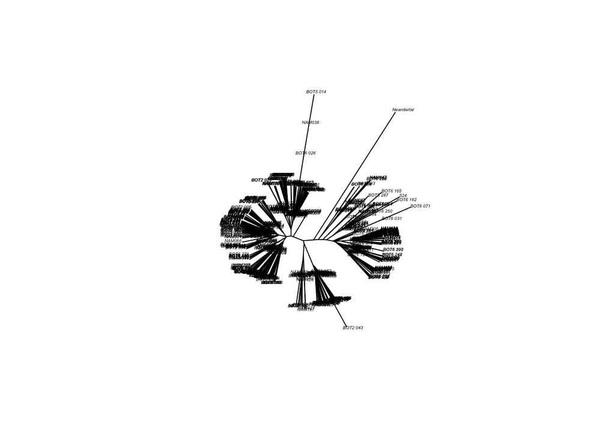

## 3. Maximum Parsimony analysis on sequences

```
fasta.phyDat  <- as.phyDat(seq) # convert to phangorn data type
njtree <- nj(dist.matrix) # Calculate NJ tree
parsimony(njtree, fasta.phyDat) # Determine the tree length of NJ tree
tree.optim <- optim.parsimony(njtree, fasta.phyDat) # more settings: weight matrix, algorithm
```

Parsimony Ratchet algorithm

```
tree.pratchet <- pratchet(fasta.phyDat, maxit=100, k=10, rearrangements="SPR")
```

Root tree: I have an outlier, a sequence from a Neandertal bone remain.

```
tree.pratchet <- root(tree.pratchet, match("Neandertal", tree.pratchet$tip.label), resolve.root=T)
```

Annotate with the number of mutations per branch

```
tree.pratchet <- acctran(tree.pratchet, fasta.phyDat)
```

Plot tree

```
plot(tree.pratchet, tip.col=colorstring, cex=0.3)
edgelabels(tree.pratchet$edge.length)
```

Write the tree to a file

```
write.tree(tree.pratchet, file="output.tree")
```

now you can open it with FigTree if you want!

Plus: check the number of mutations. How old is the root of the tree?

# 4. Haplogroup composition, population comparison

Go to: http://haplogrep.uibk.ac.at/ and import your fasta sequence alignment! Use the one printed before with only 100 sequences, there is a size limit for importing in that website. The website Haplogrep gives an automatic haplogroup assignment to full and partial mtDNA sequences.

### Correspondance Analysis

Visualize population relationships in terms of their relative haplogroup composition. First you need a table of haplogroup presence per population.

```r
info<-read.table("infomtDNAcomparison.txt",  sep="\t", header=T, as.is=T, fill=TRUE)
table(info$population)->pops
freqHG<-table(info$population, info$HG_red)
freqHG<-freqHG[-which(rownames(freqHG)=="ref"),-which(colnames(freqHG)=="ref")]
```

now we do the Correspondence Analysis with the command ca, and we plot it

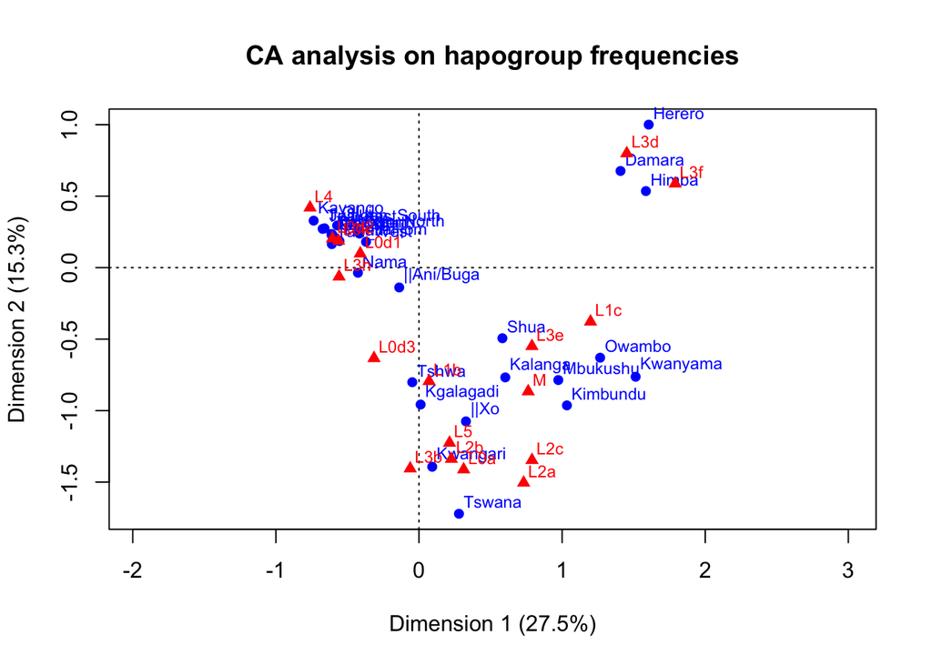

```r
ca(freqHG)-> caca
plot(caca, main="CA analysis on hapogroup frequencies")
```

# 5. MDS: bidimensional genetic distances between populations

The Muldi Dimensional Scaling processes pairwise distances and forces them in a predefined number of dimensions on a space (default bidimensional). Overview of relative similarities and dissimilarities without an evolutionary meaning. I will use an external file to add a color coding to the populations, corresponding to their Language Family.

```r
popOrder <- read.table("popOrderColor", as.is=T)
mat = read.table("matrix_mtDNA_popdist.txt",sep="\t", header=T) #matrix of distances between populations
colnames(mat)<-rownames(mat)
    replace(mat,mat <0, 0) -> m3## does not accept negative values

m4<-m3+0.0001      ## does not accept values==0
diag(m4)=0
m5<- as.dist(m4, diag=F, upper=F)

isoMDS(m5)-> distanti
```

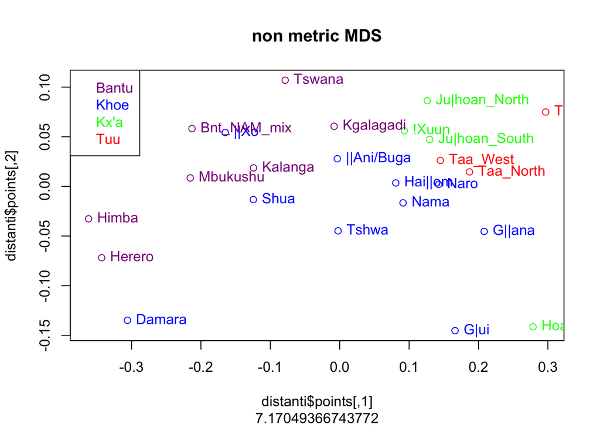

```r
distanti$points<-distanti$points[popOrder[,1],]

plot(distanti$points, , sub=distanti$stress, main="non metric MDS", col=popOrder[,2])
text(distanti$points,rownames(distanti$points), pos=4, col=popOrder[,2])
c("Bantu","Khoe","Kx'a","Tuu")->nomi
legend("topleft",nomi,text.col=c("darkmagenta","blue","green","red"))
```

# 6. Trees based on population distance

### Neighbour Joining tree populations

Visualize the same population distances with a tree (unrooted). Find outliers.

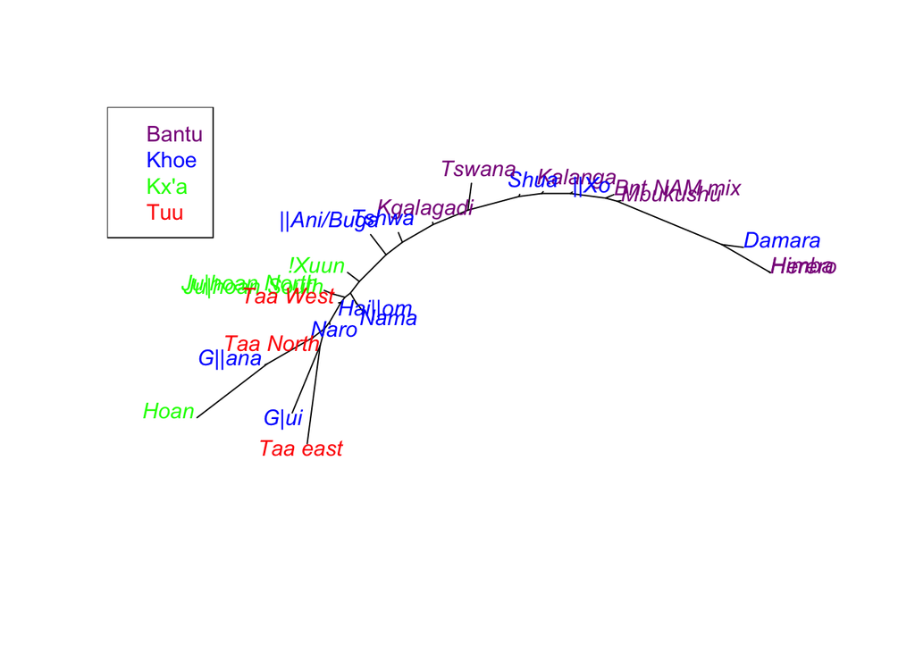

```r
m5<- as.dist(mat, diag=F, upper=F)
treeTest<-nj(m5)
treeTest$edge.length[treeTest$edge.length < 0] = 0.002
rownames(popOrder)<-popOrder[,1]
popOrder2<-popOrder[treeTest$tip.label,]
plot.phylo(treeTest, type="u", tip.col=popOrder2[,2] )
legend("topleft",nomi,text.col=c("darkmagenta","blue","green","red"))
```

### UPGMA tree populations

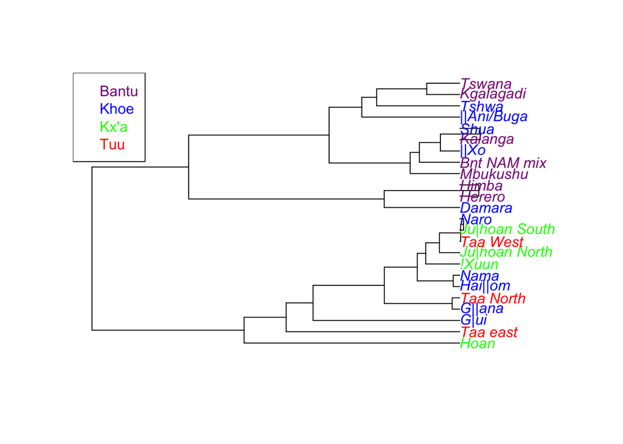

```r
upgmatree<-upgma(m5)
plot.phylo(upgmatree,  tip.col=popOrder2[,2] )
legend("topleft",nomi,text.col=c("darkmagenta","blue","green","red"))
```

What are the differences between the two trees?

### interested in Y chromosome data…?

*for questions: barbieri.chiara@gmail.com*